# Analysis - dual process and information and image treatments

# 1 Background

(from prereg)

> Participants have taken an unrelated online survey (roughly 20 minutes) in exchange for being entered into a raffle for one of twenty £50 Amazon vouchers. The chances of winning are unknown to participants but could be inferred to be of magnitude of between 1/10 and 1/300. [Ex-post note: roughly 1/20 chance]. They are asked if they would like to commit to donate part of that amount, if they win, to charity. They first choose one of two charities (guide dog charity [cost ineffective] or river blindness charity [cost effective]), or neither, to support. This choice of charity is the first dependent measure. Subsequently they indicate on a slider scale with £1 increments how much, if anything that they would like to give (commit to give). That scale represents the second dependent measure.

**Note: adapting from analysis_subst as a start**

# 2 Setup

Source the data import (cache it or not)

# 3 Literature review (models used)

# 4 Reference prereg/PaP here

# 5 Experimental Design

(see prereg)

```r
#ControlsFitme_nomood <- c(names(dplyr::select(sx_dp, sex:dimpairment, btwn_invite_dur, -birth, age, -starts_with("word"), -starts_with("eyes"), -contains("ctry2"), -contains("ctry3"))), "eyes_ correct_pct", "childpresentmdl", "clustergroup", "ordergroup", nbrnames, "happiness_1_beforeask", "student", "word_correct_pct")

#ControlsFitme <- c(ControlsEsxFitme_nomood, "mood_order_treat")
#ModeratorsEsxFitme <- ControlsEsxFitme # Same, but for 'honest' data mining work; Essex data only
```

```r
# source(here("code","Recipes.R"))
```

## 5.1 Power calculations (for 2019): (where?)

# 6 Descriptive, exploratory, ‘checking it worked’

## 6.1 Treatment allocation

*We present statistics on our sample sizes and the balance across our treatment arms*

```r
#pp("treatment allocations and balance")

(tab_treatalloc_sx_dp <- sx_dp %>%
  tabyl(treat_image, treat_eff_info) %>%
  tabylstuff_nocol(cap = "Image and effectiveness information treatments"))
```

| treat_image | Info | No info |
| --- | --- | --- |
| Image | 50.0% (95) | 50.0% (95) |
| No image | 50.0% (94) | 50.0% (94) |
| Total | 50.0% (189) | 50.0% (189) |

```r
pp("By 'river blindness first' charity ordering, effectiveness info, image treatment")
```

```
## [1] "By 'river blindness first' charity ordering, effectiveness info, image treatment"
```

```r
(tab_treatalloc_char_effect_image <- sx_dp %>%  tabyl(treat_image, treat_eff_info, d_river_1_st))
```

```
## $`FALSE`
##  treat_image Info No info
##        Image   49      48
##     No image   45      49
##
## $`TRUE`
##  treat_image Info No info
##        Image   46      47
##     No image   49      45
```

```r
pp("By prior 'aid treatment', effectiveness info, image treatment")
```

```
## [1] "By prior 'aid treatment', effectiveness info, image treatment"
```

```r
(tab_treatalloc_aid_effect_image <-sx_dp %>%  tabyl(treat_image, treat_eff_info, aid_treat))
```

```
## $int
##  treat_image Info No info
##        Image   47      46
##     No image   47      47
##
## $uk
##  treat_image Info No info
##        Image   48      49
##     No image   47      47
```

## 6.2 Summary statistics and balance tables

*Our data is rich, including over 150 survey variables and pre-treatment characteristics. To provide background on the nature of our sample, we present key demographics of our population(s).*

- Todo - major sumstats for key variables (code share with substitution paper)

*We next measure the extent to which our randomization and blocking was succesful, measuring the differences in ex-ante characteristics across treatments, as well as the difference in ``predicted donation’’ arising from this.*

Todo: balance tables of demographics (ControlsAdhocEsx?) on treatment

## 6.3 Donations (by treatment, distributions)

We present summary statistics of the donation incidence, levels, and distribution by charity and treatment.

A preliminary tab

```r
sumstats_dp <- sx_dp %>% group_by(treat_eff_info, treat_image) %>%
 summarise(mn_don =mean(donation,na.rm=TRUE),
           d_donation = mean(as.numeric(d_donation), na.rm=TRUE),#this one looks a miscode
           mn_don_river =mean(don_river,na.rm=TRUE),
           d_don_river = mean(as.numeric(d_don_river),na.rm=TRUE),
           mn_don_gd =mean(don_guide_dogs,na.rm=TRUE),
            d_don_gd = mean(as.numeric(d_don_guide_dogs),na.rm=TRUE))

sumstats_dp %>% kable(digits = 1) %>% kable_styling()
```

| treat_eff_info | treat_image | mn_don | d_donation | mn_don_river | d_don_river | mn_don_gd | d_don_gd |
| --- | --- | --- | --- | --- | --- | --- | --- |
| Info | Image | 9.1 | 1.5 | 6.0 | 1.4 | 3.0 | 1.2 |
| Info | No image | 8.8 | 1.5 | 5.8 | 1.3 | 3.0 | 1.2 |
| No info | Image | 8.4 | 1.5 | 6.5 | 1.4 | 1.9 | 1.1 |
| No info | No image | 11.0 | 1.5 | 6.4 | 1.3 | 4.6 | 1.2 |

```r
cis_dp <- sx_dp %>%  group_by(treatment) %>%
  summarise(n=n(),
            mean = ci(donation)[1],
                      lowCI = ci(donation)[2],
                      hiCI = ci(donation)[3]
                      )
cis_dp %>%  kable(caption = "Mean/ci of donations by treatment combination, all data", digits=1) %>% kable_styling()
```

| treatment | n | mean | lowCI | hiCI |
| --- | --- | --- | --- | --- |
| Control | 94 | 11.0 | 8.0 | 14 |
| Image only | 95 | 8.4 | 5.8 | 11 |
| Image-Info | 95 | 9.1 | 6.4 | 12 |
| Info only | 94 | 8.8 | 6.1 | 12 |

```r
cis_dp_geocorrect <- sx_dp %>%
  filter(attn_geog_qn=="Latin America and Africa") %>%
  group_by(treatment) %>%
  summarise(n=n(),
            mean = ci(donation)[1],
                      lowCI = ci(donation)[2],
                      hiCI = ci(donation)[3]
                      )
cis_dp_geocorrect %>% kable(caption = "Mean/ci of donations by treatment combination, correct-geography answerers only", digits=1) %>% kable_styling()
```

| treatment | n | mean | lowCI | hiCI |
| --- | --- | --- | --- | --- |
| Control | 40 | 20 | 15.1 | 25 |
| Image only | 39 | 12 | 7.2 | 16 |
| Image-Info | 40 | 13 | 7.7 | 18 |
| Info only | 46 | 12 | 8.0 | 16 |

### 6.3.1 Crosstabs

```r
(tab_don <- sx_dp %>%
  tabyl(treat_image, donation) %>%
  tabylstuff_nocol("Donations by image treatment"))
```

| treat_image | 0 | 1 | 2 | 3 | 4 | 5 | 6 | 7 | 8 | 9 | 10 | 11 | 14 | 15 | 18 | 20 | 23 | 24 | 25 | 27 | 30 | 37 | 39 | 40 | 50 |
| --- | --- | --- | --- | --- | --- | --- | --- | --- | --- | --- | --- | --- | --- | --- | --- | --- | --- | --- | --- | --- | --- | --- | --- | --- | --- |
| Image | 47.9% (91) | 2.1% (4) | 2.1% (4) | 1.1% (2) | 1.1% (2) | 7.9% (15) | 2.1% (4) | 1.6% (3) | 0.5% (1) | 0.0% (0) | 7.9% (15) | 0.5% (1) | 0.0% (0) | 2.6% (5) | 0.5% (1) | 5.8% (11) | 0.5% (1) | 0.5% (1) | 8.9% (17) | 0.0% (0) | 0.5% (1) | 0.0% (0) | 0.5% (1) | 0.5% (1) | 4.7% (9) |
| No image | 47.9% (90) | 0.5% (1) | 0.5% (1) | 1.6% (3) | 2.1% (4) | 5.3% (10) | 0.5% (1) | 0.5% (1) | 0.5% (1) | 0.5% (1) | 12.8% (24) | 0.0% (0) | 0.5% (1) | 2.1% (4) | 0.5% (1) | 2.1% (4) | 0.0% (0) | 0.0% (0) | 10.1% (19) | 1.1% (2) | 4.3% (8) | 0.5% (1) | 0.0% (0) | 0.5% (1) | 5.3% (10) |
| Total | 47.9% (181) | 1.3% (5) | 1.3% (5) | 1.3% (5) | 1.6% (6) | 6.6% (25) | 1.3% (5) | 1.1% (4) | 0.5% (2) | 0.3% (1) | 10.3% (39) | 0.3% (1) | 0.3% (1) | 2.4% (9) | 0.5% (2) | 4.0% (15) | 0.3% (1) | 0.3% (1) | 9.5% (36) | 0.5% (2) | 2.4% (9) | 0.3% (1) | 0.3% (1) | 0.5% (2) | 5.0% (19) |

```r
(tab_don <- sx_dp %>%
  tabyl(treat_eff_info, donation) %>%
  tabylstuff_nocol("Donations by effectiveness treatment"))
```

| treat_eff_info | 0 | 1 | 2 | 3 | 4 | 5 | 6 | 7 | 8 | 9 | 10 | 11 | 14 | 15 | 18 | 20 | 23 | 24 | 25 | 27 | 30 | 37 | 39 | 40 | 50 |
| --- | --- | --- | --- | --- | --- | --- | --- | --- | --- | --- | --- | --- | --- | --- | --- | --- | --- | --- | --- | --- | --- | --- | --- | --- | --- |
| Info | 47.6% (90) | 1.6% (3) | 1.1% (2) | 1.6% (3) | 2.1% (4) | 5.8% (11) | 1.1% (2) | 1.1% (2) | 0.5% (1) | 0.5% (1) | 12.7% (24) | 0.5% (1) | 0.0% (0) | 2.6% (5) | 0.5% (1) | 3.7% (7) | 0.5% (1) | 0.5% (1) | 7.9% (15) | 0.5% (1) | 1.6% (3) | 0.0% (0) | 0.5% (1) | 0.0% (0) | 5.3% (10) |
| No info | 48.1% (91) | 1.1% (2) | 1.6% (3) | 1.1% (2) | 1.1% (2) | 7.4% (14) | 1.6% (3) | 1.1% (2) | 0.5% (1) | 0.0% (0) | 7.9% (15) | 0.0% (0) | 0.5% (1) | 2.1% (4) | 0.5% (1) | 4.2% (8) | 0.0% (0) | 0.0% (0) | 11.1% (21) | 0.5% (1) | 3.2% (6) | 0.5% (1) | 0.0% (0) | 1.1% (2) | 4.8% (9) |
| Total | 47.9% (181) | 1.3% (5) | 1.3% (5) | 1.3% (5) | 1.6% (6) | 6.6% (25) | 1.3% (5) | 1.1% (4) | 0.5% (2) | 0.3% (1) | 10.3% (39) | 0.3% (1) | 0.3% (1) | 2.4% (9) | 0.5% (2) | 4.0% (15) | 0.3% (1) | 0.3% (1) | 9.5% (36) | 0.5% (2) | 2.4% (9) | 0.3% (1) | 0.3% (1) | 0.5% (2) | 5.0% (19) |

31 Jul 2019, naive eyeballs: The above shows no striking differences by either treatment arm

**Donations by treatments, summary statistics:**

```r
(tab_don_sum <- sx_dp %>%
  sumtab2_func_plus(donation, treat_image, treat_eff_info,"Donation: positive % | mean, med--p75 | (sd) [N] "))
```

Table 6.1: Donation: positive % | mean, med–p75 | (sd) [N]

| treat_image | Info | No info |
| --- | --- | --- |
| Image | 54% \| 9.1, 2–15 \| (13.3) [95] | 51% \| 8.4, 1–10 \| (12.8) [95] |
| No image | 51% \| 8.8, 3–10 \| (13.1) [94] | 53% \| 11, 3.5–25 \| (14.6) [94] |

```r
(tab_don_sum <- sx_dp %>%
  sumtab2_func_plus(don_river, treat_image, treat_eff_info,"River-blindness donation: positive %, mean, med--p75 (sd) [N]"))
```

Table 6.1: River-blindness donation: positive %, mean, med–p75 (sd) [N]

| treat_image | Info | No info |
| --- | --- | --- |
| Image | 37% \| 6, 0–6.5 \| (11.6) [95] | 36% \| 6.5, 0–6.5 \| (11.9) [95] |
| No image | 30% \| 5.8, 0–10 \| (12) [94] | 29% \| 6.4, 0–4.5 \| (12.6) [94] |

```r
(tab_don_sum <- sx_dp %>%
  sumtab2_func_plus(don_guide_dogs, treat_image, treat_eff_info,"Guide-dogs donation: positive %, mean, med--p75 (sd) [N]"))
```

Table 6.1: Guide-dogs donation: positive %, mean, med–p75 (sd) [N]

| treat_image | Info | No info |
| --- | --- | --- |
| Image | 17% \| 3.1, 0–0 \| (9) [95] | 15% \| 1.9, 0–0 \| (6.7) [95] |
| No image | 21% \| 3, 0–0 \| (7.9) [94] | 24% \| 4.6, 0–0 \| (10.6) [94] |

31 Jul 2019, naive eyeballs: The image *seems* to have lead to some increase in incidence of giving to River-Blindness, and some decrease in the incidence of giving to Guide-Dogs. This effect appears similar in each arm of the information treatment.

### 6.3.2 Histograms

**Histograms: Overall distribution of donations**

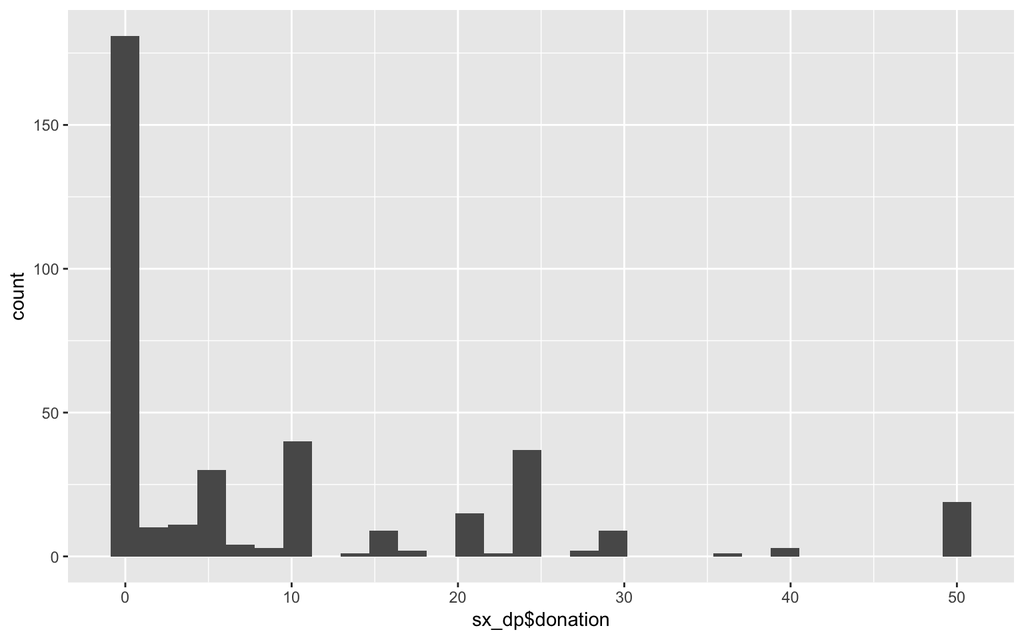

```r
ggplot(data=sx_dp, aes(sx_dp$donation)) +  geom_histogram()
```

31 Jul 2019, naive eyeballs: Donations show some clustering at round numbers: 5, 10, 20, 25, and 50. However, the ‘give the middle amount (25)’ cluster is roughly the same size as the ‘give 10’ clusters.

**Histograms: Overall donations by treatments:**

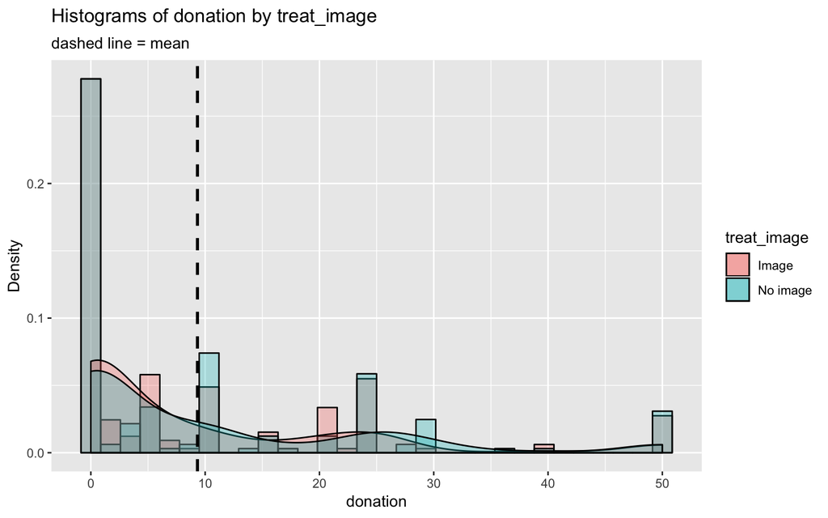

```r
plot_multi_histogram(sx_dp, "donation", "treat_image")
```

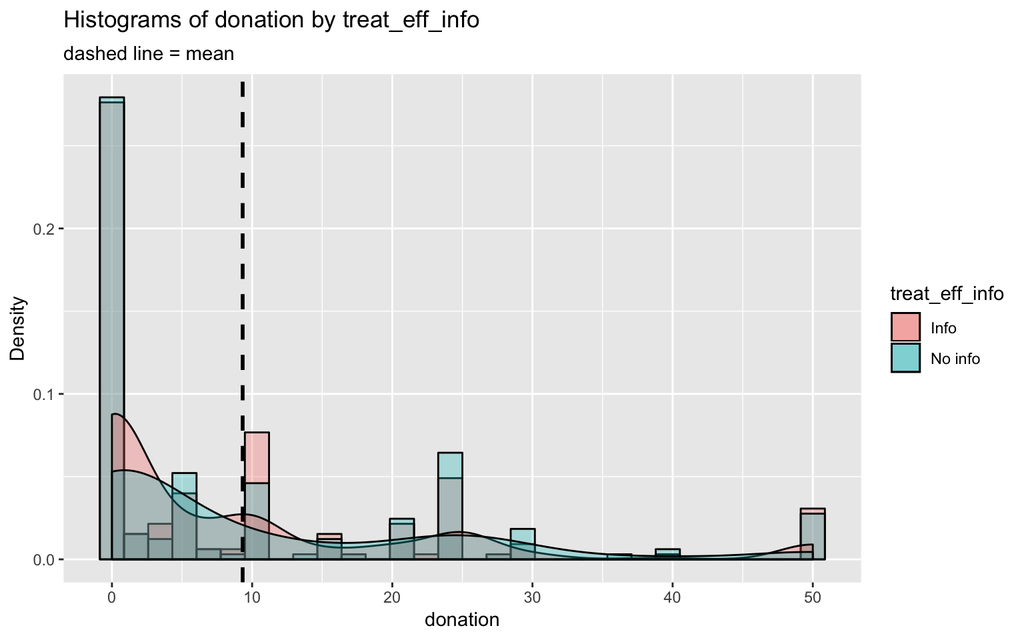

```r
plot_multi_histogram(sx_dp, "donation", "treat_eff_info")
```

31 Jul 2019, naive eyeballs: The histograms show no striking differences by either treatment arm, although we see some differences in the rate of giving £10.

**Histogram of donations by Image treatment, within info treatment**

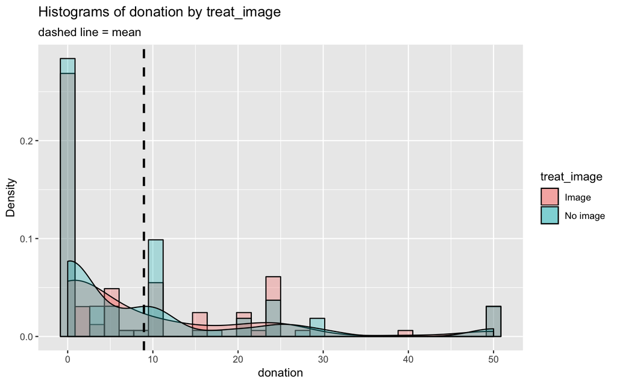

```r
plot_multi_histogram(filter(sx_dp, treat_eff_info=="Info"), "donation", "treat_image")
```

**Histogram by Image treatment, within no-info treatment**

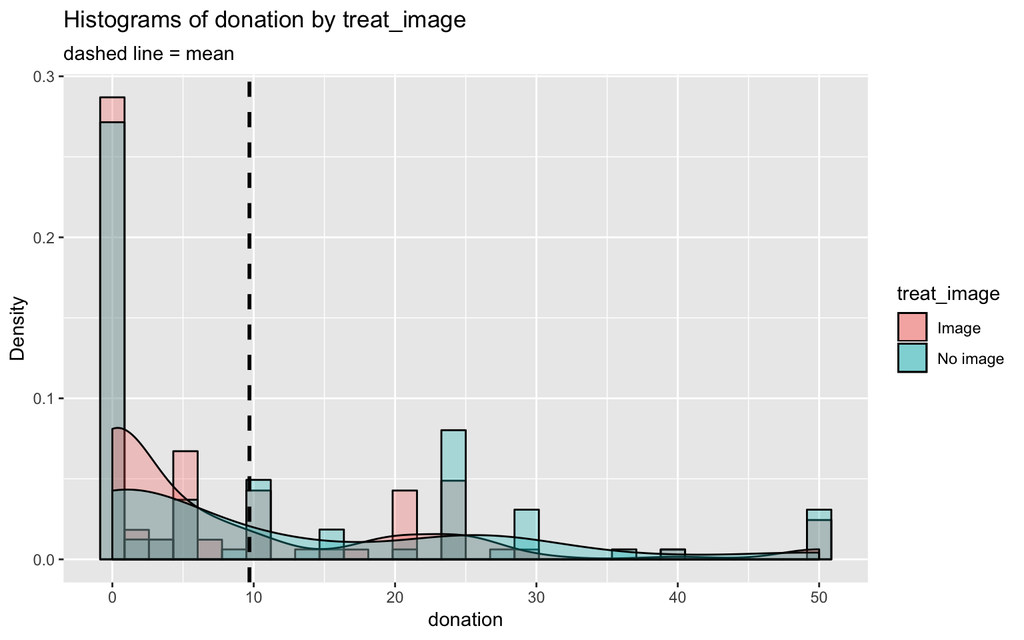

```r
plot_multi_histogram(filter(sx_dp, treat_eff_info=="No info"), "donation", "treat_image")
```

31 Jul 2019 – no striking difference

**Histograms: Donations to each charity by treatments**

```r
pp("...to guide dogs")
```

```
## [1] "...to guide dogs"
```

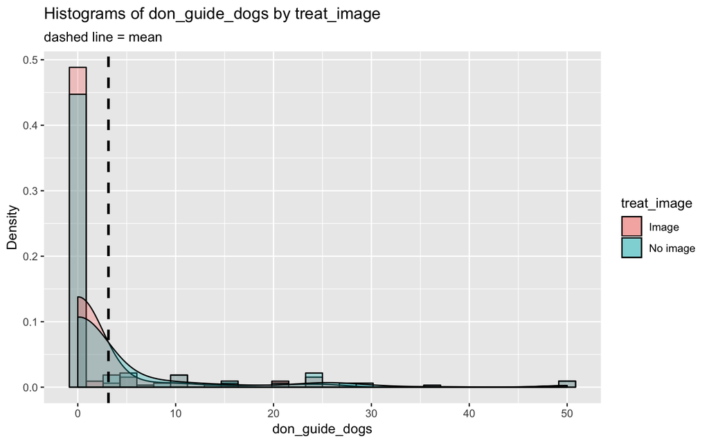

```r
plot_multi_histogram(sx_dp, "don_guide_dogs", "treat_image")
```

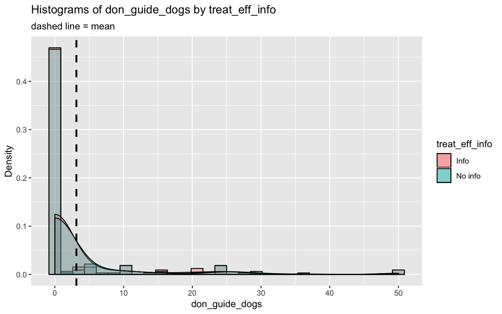

```r
plot_multi_histogram(sx_dp, "don_guide_dogs", "treat_eff_info")
```

```r
pp("...  to river blindness")
```

```
## [1] "...  to river blindness"
```

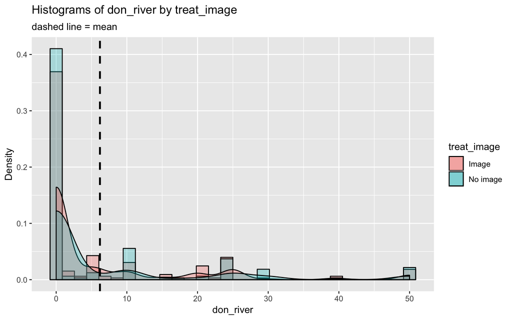

```r
plot_multi_histogram(sx_dp, "don_river", "treat_image")
```

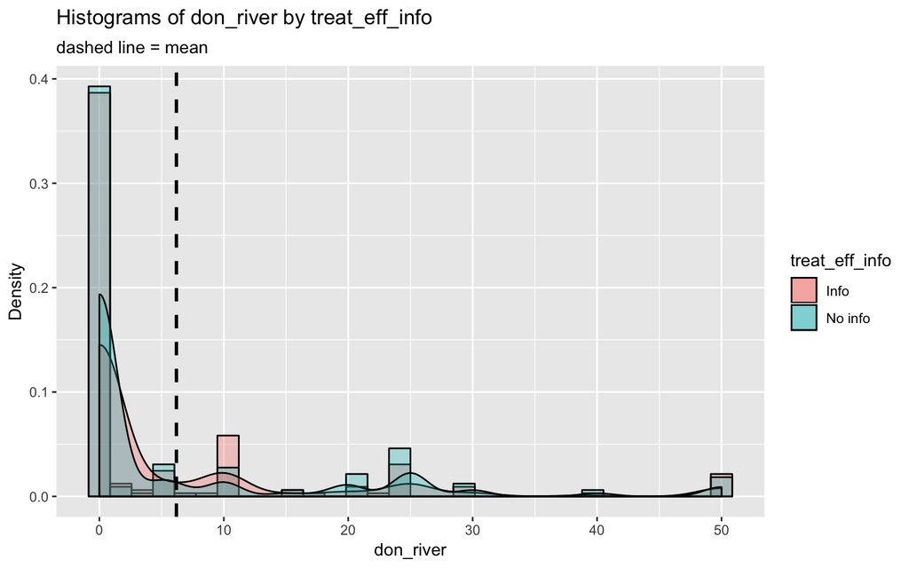

```r
plot_multi_histogram(sx_dp, "don_river", "treat_eff_info")
```

31 Jul 2019, naive eyeballs:

- for River-blindness, it looks like
  - the Image treatment causes a slight increase in the frequency of the smallest donations
  - the Effectiveness treatment caused a slight increase in the frequency of £10 donations

## 6.4 Test for normality of donation outcome

```r
sx_dp_shapiro <- shapiro.test(sx_dp$donation)
```

The results from the Shapiro Wilk normality test …

The p-values are 1.4110^{-24} suggesting this data is not normal.

# 7 Main systematic analysis

## 7.1 Working notation

…referring both to the population/true values and to the empirical equivalents of these in our experiment.

*Note, this comes largely from our PaP, but I’m adjusting some notation to agree with column names here.*

Our 2x2 design yields four combination treatments (column `treatment`):

| treatment | n | percent |
| --- | --- | --- |
| Control | 94 | 0.249 |
| Image only | 95 | 0.251 |
| Image-Info | 95 | 0.251 |
| Info only | 94 | 0.249 |

Below, $I$: `treat_image`, $C$: `treat_eff_info`

1. No treatments (control); $I=0, C=0$
2. I(mage); I=1, C=0
3. C(ost information); I=0, C=1
4. I+C; I=1, C=1

$Y$: An outcome in general; $I$: Image treatment $(0,1)$, $C$: Cost information treatment $(0,1)$; Expected value/average function $E()$, and conditioning/subsamples “$|$” operator

**Treatment effects**

1. $TE[Y](C|I=0)= E(Y|C=1,I=0) - E(Y|C=0,I=0)$ — *impact of C in the absence of I*
2. $TE[Y](C|I=1) = E(Y|C=1,I=1) - E(Y|C=0,I=1)$ — *impact of C in the presence of I*
3. $ATE[Y](C)= E(Y|C=1) - E(Y|C=0)$ — *impact of C overall, averaging across its impact in the absence/presence of E*

Outcome variables (“Y’s”):

- $d_r$, $d_g$: Individual’s donation amount (in £) to river-blindness (r) & guide-dogs (g) charities, respectively — `don_river`, `don_guide_dogs`
- $D_r$, $D_g$: Indicator $\{0,1\}$ for whether individual donated a positive amount to r & g charities, respectively — `d_don_river`,`d_don_guide_dogs`
- $d_t = d_r+d_g$ : Individual’s total donation
  - `donation`
- $D_t = D_r + D_g$: Indicator $\{0,1\}$ for whether individual donated to either charity (Note: individual can choose to donate to at most one charity.) — `d_donation`

**PAP:**

*NOTE: some adjustments made to improve notation only*

## 7.2 H1. Information about the cost effectiveness of two charities…

### 7.2.1 a. causes a greater probability of donating to the more effective one, with or without the presence of the image treatment

For the ‘participation’ in donating to river-blindness outcome, we predict (for the following conditioning groups, abusing notation a bit)

$\{C=1, I=0\} > \{C=I=0\}$

and $\{C=I=1\} > \{C=0, I=1\}$

which implies $ATE[D_r](C) > 0$; thus we will use this ‘pooled’ empirical comparison.

I.e., the population mean of `d_don_river` in the `treat_eff_info=="Info"` treatment

was predicted to exceed the mean of this variable in the “no info” treatment,

### 7.2.2 b. causes a smaller probability of donating to the less effective one,

- For the ‘participation’ in donating to guide dogs outcome, we predict
- C < control,
- C + I < I,
- which implies $ATE[D_g](C) < 0 \rightarrow$ ‘pooled’ empirical comparison (Recall that the participant must choose to donate to one or neither of the charities; they cannot donate to both)

(We focus on this pooled empirical comparison below.)

### 7.2.3 Testing H1 (incidence of donation)

**H1a-b $\rightarrow$ Fisher tests, River Blindness and Guide-dog donation incidence by Effectiveness**

(also generating results for incidence of each by Image)

```r
(rb_inc_by_eff <- sx_dp %>% tabyl(treat_eff_info, d_don_river) %>%
  knitr::kable(caption = "River-blindness donation incidence by effectiveness info", digits = 0) %>%
  kable_styling())
```

Table 7.1: River-blindness donation incidence by effectiveness info

| treat_eff_info | 0 | 1 |
| --- | --- | --- |
| Info | 126 | 63 |
| No info | 128 | 61 |

```r
(gd_inc_by_eff <- sx_dp  %>% tabyl(treat_eff_info, d_don_guide_dogs) %>%
knitr::kable(caption = "Guide-dogs donation incidence by effectiveness info", digits = 0) %>%
  kable_styling())
```

Table 7.1: Guide-dogs donation incidence by effectiveness info

| treat_eff_info | 0 | 1 |
| --- | --- | --- |
| Info | 153 | 36 |
| No info | 152 | 37 |

```r
(rb_inc_by_image <- sx_dp %>% tabyl(treat_image, d_don_river) %>%
  knitr::kable(caption = "River-blindness donation incidence by effectiveness info", digits = 0) %>%
  kable_styling())
```

| treat_image | 0 | 1 |
| --- | --- | --- |
| Image | 121 | 69 |
| No image | 133 | 55 |

```r
(gd_inc_by_eff <- sx_dp  %>% tabyl(treat_image, d_don_guide_dogs) %>%
knitr::kable(caption = "Guide-dogs donation incidence by effectiveness info", digits = 0) %>%
  kable_styling())
```

| treat_image | 0 | 1 |
| --- | --- | --- |
| Image | 160 | 30 |
| No image | 145 | 43 |

```r
FT_treat_eff_info_river <- fisher.bintest(d_don_river ~ treat_eff_info, sx_dp, alpha = 0.05, p.method = "fdr")
FT_treat_eff_info_gd <- fisher.bintest(d_don_guide_dogs ~ treat_eff_info, sx_dp, alpha = 0.05, p.method = "fdr")
FT_treat_image_river <- fisher.bintest(d_don_river ~ treat_image, sx_dp, alpha = 0.05, p.method = "fdr")
FT_treat_image_gd <- fisher.bintest(d_don_guide_dogs ~ treat_image, sx_dp, alpha = 0.05, p.method = "fdr")

FT_chars <- list(FT_treat_eff_info_river, FT_treat_eff_info_gd,FT_treat_image_river,FT_treat_image_gd)
FTnames <- c("Effectiveness: RB", "Effectiveness: GD", "Image: RB", "Image: GD")

FT_chars[[1]]$method <- "Fisher"
FT_chars[[2]]$method <- "Fisher"
FT_chars[[3]]$method <- "Fisher"
FT_chars[[4]]$method <- "Fisher"

FT_chars  <- map2(FT_chars, FTnames, function(x, y) {
  broom::tidy(x) %>% add_column(Experiment = y)
})

#todo: make this dplyr/tidy/pipey



FT_chars <- FT_chars%>%
  bind_rows() %>%
  kable(, caption = "Donation incidence by Image and Effectiveness-info treatments; Fisher tests", digits = 2) %>%
  kable_styling()

FT_chars
```

| estimate | p.value | conf.low | conf.high | method | alternative | Experiment |
| --- | --- | --- | --- | --- | --- | --- |
| 1.05 | 0.91 | 0.67 | 1.6 | Fisher | two.sided | Effectiveness: RB |
| 0.97 | 1.00 | 0.56 | 1.7 | Fisher | two.sided | Effectiveness: GD |
| 1.38 | 0.16 | 0.88 | 2.2 | Fisher | two.sided | Image: RB |
| 0.63 | 0.09 | 0.36 | 1.1 | Fisher | two.sided | Image: GD |

31 Jul 2019: The Fisher tests reported above do not show a substantial difference in either case, failing to confirm H1a and H1b. However, examining, the 95% confidence intervals, we also can not rule out a substantial effect (in either direction). These CI’s encompass odds roughly between 3:2 and 2:3.

Ex-post, our experiment appears under-powered for testing this hypothesis (note that our sample size was also less than the desired size).

## 7.3 H2. Empathy-evoking images increase the propensity to donate a positive amount (rather than not donate); i.e., a greater ‘donation incidence’,

For the ‘donate something’ outcome, we predict

- E > control
- E + C > E
- which implies ATED_t > 0, $\rightarrow$ ‘pooled’ empirical comparison

**Testing H2: Computing Fisher tests for OVERALL donation incidence**

```r
options(digits = 3)

don_inc <- sx_dp %>%
  group_by(treat_image, treat_eff_info) %>%
  dplyr::summarize(donated = mean(as.numeric(d_donation))-1, don_gd = mean(as.numeric(d_don_guide_dogs))-1, don_river = mean(as.numeric(d_don_river))-1, n=n()) %>%
  kable() %>%
  kable_styling()


#info

sx_dp %>% tabyl(treat_eff_info,d_donation) %>%
knitr::kable(, caption = "Donation incidence by effectiveness info", digits = 0) %>%
  kable_styling()
```

Table 7.2: Donation incidence by effectiveness info

| treat_eff_info | 1 | 2 |
| --- | --- | --- |
| Info | 90 | 99 |
| No info | 91 | 98 |

```r
FT_treat_info_only <- fisher.bintest(d_donation ~ treat_eff_info, filter(sx_dp,treat_image=="No image"), alpha = 0.05, p.method = "fdr")

FT_treat_add_info <- fisher.bintest(d_donation ~ treat_eff_info, filter(sx_dp,treat_image=="Image"), alpha = 0.05, p.method = "fdr")


FT_treat_eff_info <- fisher.bintest(d_donation ~ treat_eff_info, sx_dp, alpha = 0.05, p.method = "fdr")

FT <- list(FT_treat_info_only, FT_treat_add_info, FT_treat_eff_info)
FTnames <- c("Effectiveness vs control", "Effectiveness| Image present", "Effectiveness (pooled)")
FT <- map2(FT, FTnames, function(x, y) {
  broom::tidy(x) %>% add_column(Experiment = y)
})

FT[[1]]$method <- "Fisher"
FT[[2]]$method <- "Fisher"
FT[[3]]$method <- "Fisher"

FT <- FT %>%
  bind_rows() %>%
  kable(, caption = "Donation incidence by Effectiveness-info treatments; Fisher tests", digits = 2) %>%
  kable_styling()

FT
```

| estimate | p.value | conf.low | conf.high | method | alternative | Experiment |
| --- | --- | --- | --- | --- | --- | --- |
| 0.919 | 0.884 | 0.498 | 1.69 | Fisher | two.sided | Effectiveness vs control |
| 1.134 | 0.772 | 0.617 | 2.09 | Fisher | two.sided | Effectiveness\| Image present |
| 1.021 | 1.000 | 0.669 | 1.56 | Fisher | two.sided | Effectiveness (pooled) |

31 Jul 2019: The relevant Fisher tests are reported in the table above. We can not confirm H2 nor any of its component hypotheses. As for H1, we also have wide confidence intervals.

```r
sx_dp %>% tabyl(treat_eff_info, d_don_river) %>%
  knitr::kable(caption = "River-blindness donation incidence by effectiveness info", digits = 0) %>%
  kable_styling()
```

Table 7.3: River-blindness donation incidence by effectiveness info

| treat_eff_info | 0 | 1 |
| --- | --- | --- |
| Info | 126 | 63 |
| No info | 128 | 61 |

```r
sx_dp %>% tabyl(treat_eff_info, d_don_guide_dogs) %>%
knitr::kable(caption = "Guide-dogs donation incidence by effectiveness info", digits = 0) %>%
  kable_styling()
```

Table 7.3: Guide-dogs donation incidence by effectiveness info

| treat_eff_info | 0 | 1 |
| --- | --- | --- |
| Info | 153 | 36 |
| No info | 152 | 37 |

```r
FT_treat_eff_info_river <- fisher.bintest(d_don_river ~ treat_eff_info, sx_dp, alpha = 0.05, p.method = "fdr")
FT_treat_eff_info_gd <- fisher.bintest(d_don_guide_dogs ~ treat_eff_info, sx_dp, alpha = 0.05, p.method = "fdr")

FT_chars_ef <- list(FT_treat_eff_info_river, FT_treat_eff_info_gd)
FTnames <- c("Effectiveness: RB", "Effectiveness: GD")

FT_chars_ef  <- map2(FT_chars, FTnames, function(x, y) {
  broom::tidy(x) %>% add_column(Experiment = y)
})

#todo: make this dplyr/tidy/pipey

FT_chars_ef[[1]]$method <- "Fisher"
FT_chars_ef[[2]]$method <- "Fisher"

FT_chars_ef_k <- FT_chars_ef%>%
  bind_rows() %>%
  kable(, caption = "Donation incidence by Image and Effectiveness-info treatments; Fisher tests", digits = 2) %>%
  kable_styling()

FT_chars_ef_k
```

[output not shown]

## 7.4 H3. Cost effectiveness information interacts with the empathy-inducing image such that an image alone generates greater donation amounts compared to image combined with effectiveness information

Equivalently, adding Cost to Empathy reduces donation (incidence and amounts) relative to Empathy alone.

- We predict, for both the ‘total amount donated’ and ‘donate something’ outcomes: I > I+C Similarly,
1. TEd_t < 0
2. TED_t < 0

# 8 Todo: incorporate work below into systematic PaP-based analysis

## 8.1 Simple statistical tests for treatment differences

```r
# t-test Donations

pp("Defining treatment combinations here")
```

```
## [1] "Defining treatment combinations here"
```

```r
TreatCombinations <- split(combn(levels(sx_dp$treatment), 2), rep(1:ncol(combn(levels(sx_dp$treatment), 2)), each = nrow(combn(levels(sx_dp$treatment), 2)))) # get treatment combinations into a list of column vectors

pp("Key comparisons")
```

```
## [1] "Key comparisons"
```

## 8.2 Plotting contributions by treatments

```r
# todo: sx_dp/EX/GT together?

#DotPlotsxcolours <- c( `No ask-Domestic` = "red2", `No ask-Internat.` = "blue3", )
#DotPlotsxshapes <- c( `No ask-Domestic` = 0, `No ask-Internat.` = 1, )

# (DotPlotsx17 <- sx_dp %>%
#   mutate(stage = as.numeric(stage)) %>%
#   filter(treatment != "No ask-Attrite", year == 2017) %>%
#   dotplot_func(donation, stage, treatment, "Essex 2017: mean donations by stage, treatment, attrition") +
#   scale_colour_manual(values = DotPlotsxcolours) +
#   scale_shape_manual(values = DotPlotsxshapes))
```

## 8.3 Boxplots: donation by treatment, tests of differences

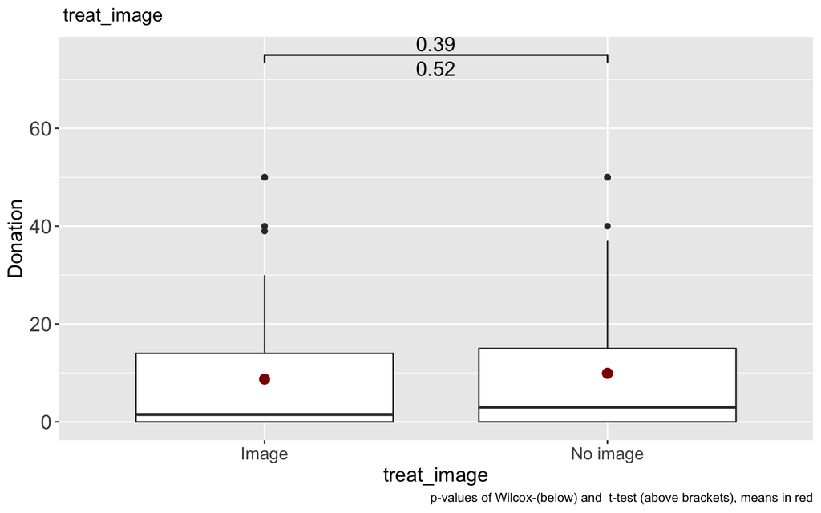

```r
(BoxPlots_dp_image<- sx_dp %>%
  boxplot_func_m(donation, treat_image, comparisons = list(c("Image", "No image"))) +
  ylab("Donation"))
```

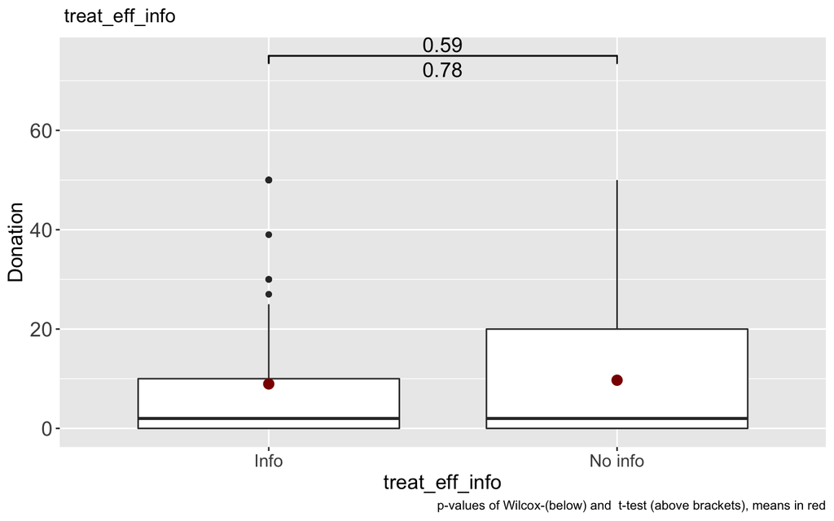

```r
(BoxPlots_dp_info <- sx_dp %>%
  boxplot_func_m(donation, treat_eff_info, comparisons = list(c("Info", "No info"))) +
  ylab("Donation"))
```

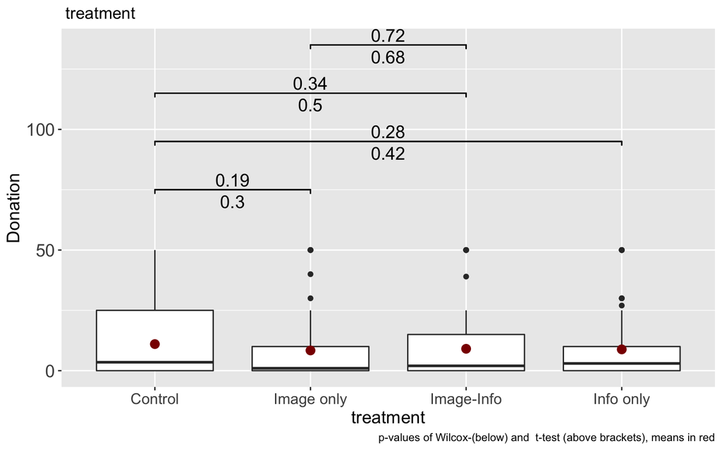

```r
(BoxPlots_dp <- sx_dp %>%
  boxplot_func_m(donation, treatment, comparisons = list(c("Control", "Image only"), c("Control", "Info only"), c("Control", "Image-Info"), c("Image only", "Image-Info"))) +
  ylab("Donation"))
```

Donations to guide dogs only:

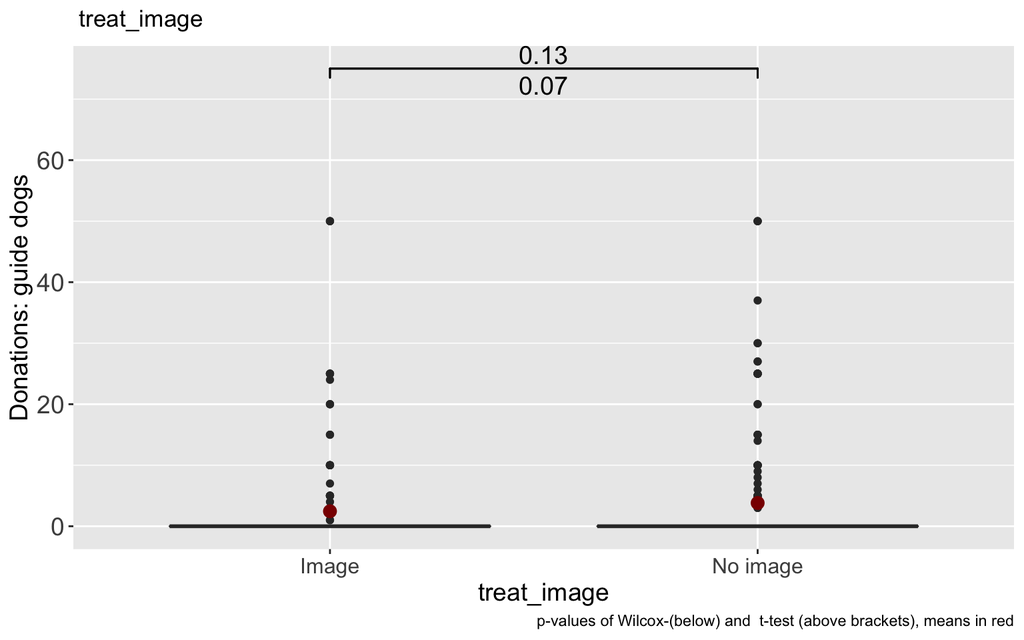

```r
(BoxPlots_dp_image_gd<- sx_dp %>%
  boxplot_func_m(don_guide_dogs, treat_image, comparisons = list(c("Image", "No image"))) +
  ylab("Donations: guide dogs"))
```

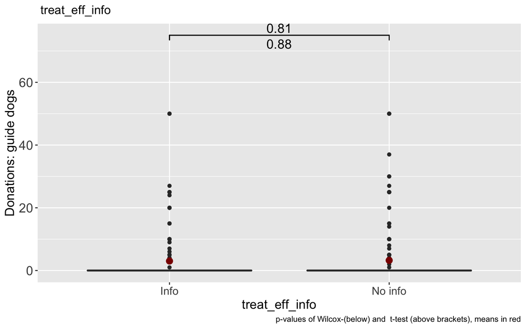

```r
(BoxPlots_dp_info_gd <- sx_dp %>%
  boxplot_func_m(don_guide_dogs, treat_eff_info, comparisons = list(c("Info", "No info"))) +
  ylab("Donations: guide dogs"))
```

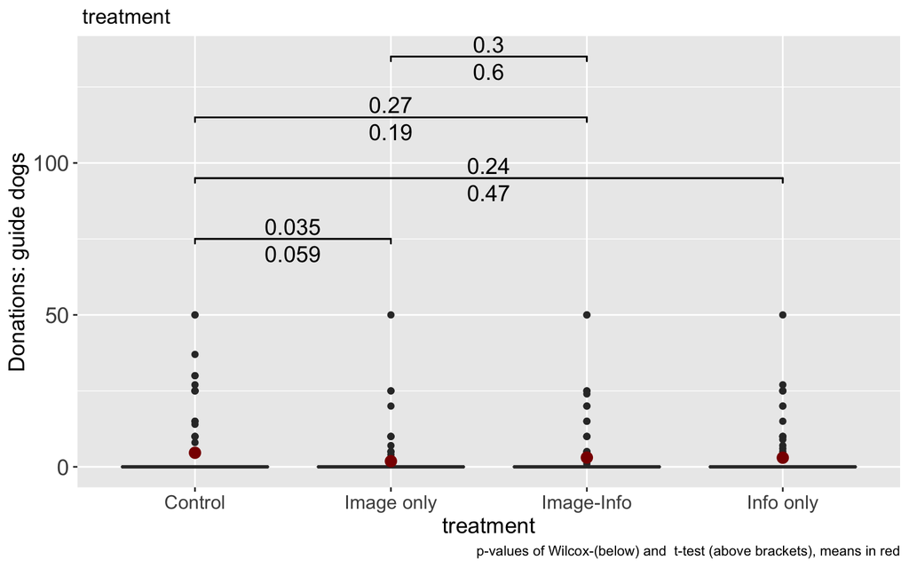

```r
(BoxPlots_dp_gd <- sx_dp %>%
  boxplot_func_m(don_guide_dogs, treatment, comparisons = list(c("Control", "Image only"), c("Control", "Info only"), c("Control", "Image-Info"), c("Image only", "Image-Info"))) +
  ylab("Donations: guide dogs"))
```

```r
pp("Donations to river blindness only")
```

```
## [1] "Donations to river blindness only"
```

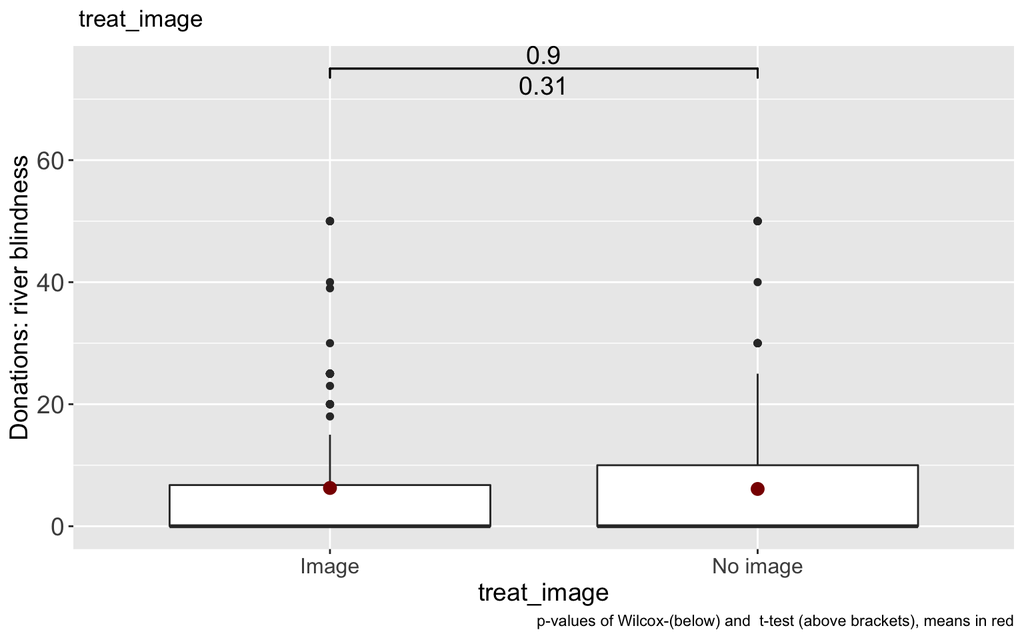

```r
(BoxPlots_dp_image_rb <- sx_dp %>%
  boxplot_func_m(don_river, treat_image, comparisons = list(c("Image", "No image"))) +
  ylab("Donations: river blindness"))
```

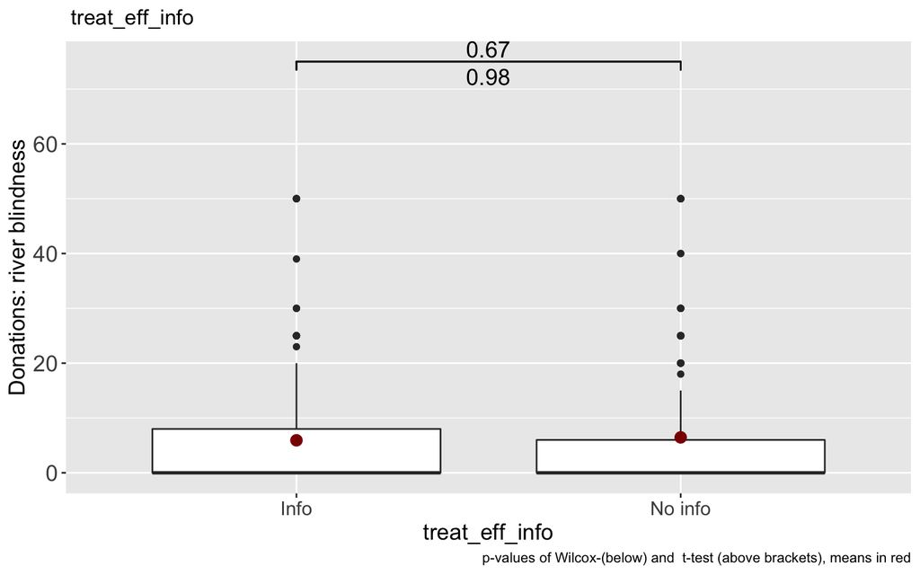

```r
(BoxPlots_dp_info_rb <- sx_dp %>%
  boxplot_func_m(don_river, treat_eff_info, comparisons = list(c("Info", "No info"))) +
  ylab("Donations: river blindness"))
```

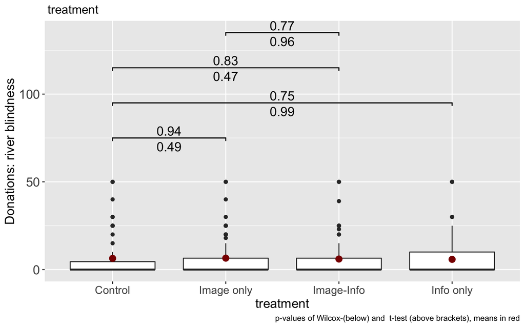

```r
(BoxPlots_dp_rb <- sx_dp %>%
  boxplot_func_m(don_river, treatment, comparisons = list(c("Control", "Image only"), c("Control", "Info only"), c("Control", "Image-Info"), c("Image only", "Image-Info"))) +
  ylab("Donations: river blindness"))
```

*Comments on previous chunk:*

PAP:

Boxplot comparisons … faceted

BELOW: code not evaluated (old)

```r
#BELOW: code not evaluated (old)

# Todo: let's line these up side by side - 2017, 2019, pooled
# PlotAskNoAsk <- sxB %>% ggplot(aes(donation, colour = treat_no_ask)) +
#  stat_ecdf(geom = "step")

comparisons <- list(c("Asked", "No ask"))
bpltDon_17 <- sx_dp %>%
  filter(year == 2017, stage == "2", d_attrited == 0) %>%
  boxplot_func(donation, treat_no_ask, comparisons = comparisons) + ylab("Donation")
bpltDon_17
bpltDon_19 <- sx_dp %>%
  filter(year == 2019, stage == "2", d_attrited == 0) %>%
  boxplot_func_m(donation, treat_no_ask, comparisons = comparisons) +
  ylab("Donation")
bpltDon_19
# ...ggboxplot(x = "treat_no_ask", y = "donation", color = "treat_no_ask", palette =c("#00AFBB", "#E7B800"), shape = "treat_no_ask") + stat_compare_means(label="t.test", comparisons = comparisons, method = "t.test")

bpltDon_17_19 <- sx_dp %>%
  filter(stage == "2", d_attrited == 0) %>%
  boxplot_func(donation, treat_no_ask, comparisons = comparisons) + ylab("Donation")
bpltDon_17_19
#############################################

sx_dp$student <- fct_recode(sx_dp$student, "Student" = "1", "Non student" = "0")

bplt_facet_Don_17_19 <- sx_dp %>%
  filter(stage == "2", d_attrited == 0) %>%
  ggplot(aes(treat_no_ask, donation)) +
  geom_boxplot() +
  ylab("Donation") +
  stat_summary(
    fun.y = mean, geom = "point", shape = 18,
    size = 3, color = "red"
  ) +
  facet_grid(student ~ year)

pp("By year and (2017) student status")

bplt_facet_Don_17_19 <- sx_dp %>%
  filter(stage == "2", d_attrited == 0) %>%
  ggplot(aes(treat_no_ask, donation)) +
  geom_boxplot() +
  ylab("Donation") +
  facet_grid(student ~ year) +
  geom_signif(
    comparisons = comparisons,
    step_increase = c(.4), vjust = 1.7, margin_top = .7, textsize = 3
  ) +
  geom_signif(
    comparisons = comparisons,
    step_increase = c(.4), vjust = 0, margin_top = .7, textsize = 3, test = "t.test"
  ) +
  theme(
    axis.title = element_text(size = 14),
    axis.text = element_text(size = 14)
  ) +
  theme(axis.text.x = element_text(size = 12)) +
  labs(title = "treatment", y = "donation", caption = "p-values of Wilcox-(below) and  t-test (above brackets)") +
  stat_summary(
    fun.y = mean, geom = "point", shape = 18,
    size = 3, color = "red"
  )
bplt_facet_Don_17_19

pp("by time delay between asks")
bplt_facet_start_Don_19t <- sx_dp %>%
  filter(stage == "2", d_attrited == 0, year == 2019) %>%
  ggplot(aes(treat_no_ask, donation)) +
  geom_boxplot() +
  ylab("Donation") +
  facet_grid(~ floor(btwn_invite_dur)) +
  #  geom_signif(comparisons = comparisons,
  #                step_increase = c(.4), vjust = 1.7, margin_top = .7, textsize = 3) +
  #  geom_signif(comparisons = comparisons,
  #              step_increase = c(.4), vjust = 0, margin_top = .7, textsize = 3, test = "t.test") +
  theme(
    axis.title = element_text(size = 14),
    axis.text = element_text(size = 14)
  ) +
  theme(axis.text.x = element_text(size = 12)) +
  labs(title = "treatment", y = "donation", caption = "p-values of Wilcox-(below) and  t-test (above brackets)") +
  stat_summary(
    fun.y = mean, geom = "point", shape = 18,
    size = 3, color = "red"
  )

bplt_facet_start_Don_19t

pp("by charity similarity")

bplt_facet_similarity_Don_sim <- sx_dp %>%
  drop_na(treat_sim_dif) %>%
  filter(stage == "2", d_attrited == 0) %>%
  ggplot(aes(treat_sim_dif, donation)) +
  geom_boxplot() +
  ylab("Donation") +
  geom_signif(
    comparisons = c(1, 2),
    step_increase = c(.4), vjust = 1.7, margin_top = .7, textsize = 3
  ) +
  geom_signif(
    comparisons = c(1, 2),
    step_increase = c(.4), vjust = 0, margin_top = .7, textsize = 3, test = "t.test"
  ) +
  theme(
    axis.title = element_text(size = 14),
    axis.text = element_text(size = 14)
  ) +
  theme(axis.text.x = element_text(size = 12)) +
  labs(title = "treatment", y = "donation", caption = "p-values of Wilcox-(below) and  t-test (above brackets)") +
  stat_summary(
    fun.y = mean, geom = "point", shape = 18,
    size = 3, color = "red"
  )

bplt_facet_similarity_Don_sim

pp("By charity similarity, total donations")
bplt_facet_similarity_don_sim_tot <- sx_dp %>%
  filter(stage == "2", d_attrited == 0) %>%
  ggplot(aes(treat_sim_dif, total_don)) +
  geom_boxplot() +
  ylab("Total don") +
  geom_signif(
    comparisons = c(1, 2),
    step_increase = c(.4), vjust = 1.7, margin_top = .7, textsize = 3
  ) +
  geom_signif(
    comparisons = c(1, 2),
    step_increase = c(.4), vjust = 0, margin_top = .7, textsize = 3, test = "t.test"
  ) +
  theme(
    axis.title = element_text(size = 14),
    axis.text = element_text(size = 14)
  ) +
  theme(axis.text.x = element_text(size = 12)) +
  labs(title = "treatment", y = "Total don", caption = "p-values of Wilcox-(below) and  t-test (above brackets)") +
  stat_summary(
    fun.y = mean, geom = "point", shape = 18,
    size = 3, color = "red"
  )

bplt_facet_similarity_don_sim_tot
```

Box plots, charity pairings (?)…

```r
# todo: better ordering of treatments

box_charpairings_17 <- sx_dp %>%
  filter(year == 2017, stage == "2", d_attrited == 0) %>%
  boxplot_func(donation, treatment, comparisons = list(c("No ask-Domestic", "Domestic-Domestic"), c("No ask-Internat.", "Internat.-Internat."))) +
  ylab("Donation") +
  stat_summary(
    fun.y = mean, geom = "point", shape = 18,
    size = 3, color = "red"
  )
box_charpairings_17

box_charpairings_19 <- sx_dp %>%
  filter(year == 2019, stage == "2", d_attrited == 0) %>%
  boxplot_func(donation, treatment, comparisons = list(c("No ask-Domestic", "Domestic-Domestic"), c("No ask-Internat.", "Internat.-Internat."))) +
  ylab("Donation") +
  stat_summary(
    fun.y = mean, geom = "point", shape = 18,
    size = 3, color = "red"
  )
box_charpairings_19

box_charpairings_17_19 <- sx_dp %>%
  filter(stage == "2", d_attrited == 0) %>%
  boxplot_func(donation, treatment, comparisons = list(c("No ask-Domestic", "Domestic-Domestic"), c("No ask-Internat.", "Internat.-Internat."))) +
  ylab("Donation") +
  stat_summary(
    fun.y = mean, geom = "point", shape = 18,
    size = 3, color = "red"
  )

box_charpairings_17_19

box_similar_19 <- sx_dp %>%
  filter(year == 2019, stage == "2", d_attrited == 0) %>%
  boxplot_func(donation, treat_sim, comparisons = list(c("No ask", "Similar"), c("No ask", "Different"))) +
  stat_summary(
    fun.y = mean, geom = "point", shape = 18,
    size = 3, color = "red"
  ) +
  ylab("Donation")
box_similar_19
```

## 8.4 Regression analysis

Below, we (plan to) run the ‘matrix’ of regressions (iterate function?) for

- outcomes
- pooled/disagreggated treatments
- functional forms …? linear, Poisson-exponential, (tobit), (quantile?)
- no ‘noise-reduction’ controls, ad-hoc controls, model-fit controls (Ridge Regression with regularization over noise variables only)

Work on creating recipes…

```r
sxm <- sx_dp %>% select(donation, d_donation, total_don, firstasktreat, matches("treat|decision|btwn|dur|aid|EyesCorrectPct|^d_|country_birth|student|salaryrequest_1|ask|dur|educ|mom|dad|political|worth|respect|trust|risk|satisfaction|no_good|redist|private_redist|^uk|tax_share|children|birth_nation", -matches("seconds|sbeforeask|dur_survey.2|Duration (in seconds).2|lose|mx25|beforeask")),  to_snake_case(hroot_vars))

# sx_r <- recipes::recipe(donation+d_donation+total_don~., data = sxm) %>%
#   step_meanimpute(all_numeric(), -all_outcomes()) %>%  step_knnimpute(all_nominal()) %>%  step_center(all_numeric(), -all_outcomes()) %>% step_scale(all_numeric(), -all_outcomes()) %>%  step_other(all_nominal()) %>% #all nominal variables with lt 5% ofgg obs --> other
#   prep(training = sxm) %>%  recipes::bake(sxm)
```

### 8.4.1 ‘regular’ regressions

(some regressions put into tables with Huxtable below)

(Regressions-with-controls-not-for-lee)

```r
# create design matrix
# rec_donationSX in recipes.R

# suppressWarnings(try(sxprep <- prep(rec_donationSX, retain = TRUE) %>% juice()))

# trying out simple models-- cut?

model0 <- lm(donation ~ treat_image+treat_eff_info, data = sx_dp)
model1 <- lm(donation ~ treat_image*treat_eff_info, data = sx_dp)
model2 <- lm(don_guide_dogs ~  treat_image*treat_eff_info + d_river_1st, data = sx_dp)
model3 <- lm(don_river ~  treat_image*treat_eff_info + d_river_1st, data = sx_dp)

hux_ols_don <- huxreg(model0,model1, model2, model3, ci_level = .95, error_format = "[{conf.low}, {conf.high}]")

hux_ols_don
# todo - format this table with kable

IndepVars <- paste(ControlsAdhocEsx, collapse = " + ") %>%
  paste("~", .)

ControlsAdhocEsx_dp <- c("sex", "age", "race", "P_Sympathetic_Warm", "essex_uni_student", "EyesCorrectPct", "V_benevolence", "V_universalism", "trust", "risk_willingness", "self_worth", "decision_mode", "mood_order_treat_1", "mood_order_treat")

# variables "childpresentmdl", "clustergroup"

IndepVars_s <- paste(ControlsAdhocEsxs, collapse = " + ") %>%
  paste("~", .)

# Second stage total/incidence
# Overall effect of first ask
# Decision mode

######################################################################

pp("Overall effect of first ask on second donation:")

ols_don_tr_noask <- lm(donation ~ treat_no_ask, data = sx_dp %>% filter(stage == "2"))
ols_don_tr_noask_2017 <- lm(donation ~ treat_no_ask, data = sx_dp %>% filter(stage == "2" & year == 2017))
ols_don_tr_noask_2019 <- lm(donation ~ treat_no_ask, data = sx_dp %>% filter(stage == "2" & year == 2019))

hux_ols_don_tr_noask <- huxreg("Pooled" = ols_don_tr_noask, "2017" = ols_don_tr_noask_2017, "2019" = ols_don_tr_noask_2019, ci_level = .95, error_format = "[{conf.low}, {conf.high}]")

hux_ols_don_tr_noask

ols_dond_tr_noask <- lm(as.double(d_donation) ~ treat_no_ask, data = sx_dp %>% filter(stage == "2"))
ols_dond_tr_noask_2017 <- lm(as.double(d_donation) ~ treat_no_ask, data = sx_dp %>% filter(stage == "2" & year == 2017))
ols_dond_tr_noask_2019 <- lm(as.double(d_donation) ~ treat_no_ask, data = sx_dp %>% filter(stage == "2" & year == 2019))

hux_ols_dond_tr_noask <- huxreg("Pooled" = ols_dond_tr_noask, "2017" = ols_dond_tr_noask_2017, "2019" = ols_dond_tr_noask_2019, ci_level = .95, error_format = "[{conf.low}, {conf.high}]")


pp("Overall effect of first ask on second donation INCIDENCE:")

hux_ols_dond_tr_noask

pp("By SIMILARITY:")

ols_don_sim_noask <- lm(donation ~ treat_sim, data = sx_dp %>% filter(stage == "2"))
ols_don_sim_noask_2017 <- lm(donation ~ treat_sim, data = sx_dp %>% filter(stage == "2" & year == 2017))
ols_don_sim_noask_2019 <- lm(donation ~ treat_sim, data = sx_dp %>% filter(stage == "2" & year == 2019))

hux_ols_don_sim_noask <- huxreg("Pooled" = ols_don_sim_noask, "2017" = ols_don_sim_noask_2017, "2019" = ols_don_sim_noask_2019, ci_level = .95, error_format = "[{conf.low}, {conf.high}]")

hux_ols_don_sim_noask

pp("Overall effect of first ask on TOTAL donation, by similarity")

ols_tdon_sim_noask <- lm(total_don ~ treat_sim, data = sx_dp %>% filter(stage == "2"))
ols_tdon_sim_noask_2017 <- lm(total_don ~ treat_sim, data = sx_dp %>% filter(stage == "2" & year == 2017))
ols_tdon_sim_noask_2019 <- lm(total_don ~ treat_sim, data = sx_dp %>% filter(stage == "2" & year == 2019))

hux_ols_tdon_sim_noask <- huxreg("Pooled" = ols_tdon_sim_noask, "2017" = ols_tdon_sim_noask_2017, "2019" = ols_tdon_sim_noask_2019, ci_level = .95, error_format = "[{conf.low}, {conf.high}]")

hux_ols_tdon_sim_noask


# Overall by time differential
pp("# Overall by time differential")

ols_don_noaskXdur_2019 <- lm(donation ~ treat_no_ask * as.factor(round(btwn_invite_dur)), data = sx_dp %>% filter(stage == "2" & year == 2019))

hux_ols_don_noaskXdur_2019 <- huxreg(ols_don_noaskXdur_2019)
# hux_ols_don_noaskXdur_2019

huxreg(ols_don_noaskXdur_2019, ci_level = .95, error_format = "[{conf.low}, {conf.high}]")

# Decision mode
pp("Decision mode")

ols_don_noaskXdec_mode_2019 <- lm(donation ~ treat_no_ask * d_decis_intu, data = sx_dp %>% filter(stage == "2" & year == 2019))

ols_don_simXdec_mode_2019 <- lm(donation ~ treat_sim * d_decis_intu, data = sx_dp %>% filter(stage == "2" & year == 2019))

huxreg(ols_don_noaskXdec_mode_2019, ols_don_simXdec_mode_2019)


CrossReg <- cross2(DonOutVars, IndepVars_s) %>%
  map(purrr::lift(paste)) %>%
  unlist() # sets up linear model arguments for each of the DonOutVars

linreg <- function(relation) {
  # regstr <- paste(DepVar, " ~ ", )
  model <- lm(as.formula(relation), data = subset(sx_dp, stage == "2"))
  model
}

# try(models <- map(CrossReg, linreg)) # runs lm for each of "CrossReg" models
# if you include the varls  "childpresentmdl", "clustergroup" --> Error in `contrasts<-`(`*tmp*`, value = contr.funs[1 + isOF[nn]]) :  contrasts can be applied only to factors with 2 or more levels
# ... these (and all varls) need to be imputed where missing

sx_fixNA <- sx_dp %>% NA_preproc()

lik7_levels <- c("Disagree Strongly", "Disagree Moderately", "Disagree a little", "Neither agree nor disagre", "Agree a little", "Agree Moderately", "Agree Strongly")

# sx_fixNA <- sx_dp %>% NA_preproc()
# sxcplt <- sx_fixNA[complete.cases(as.data.frame(sx_fixNA[ControlsEsxFitme])), ]

# NOTE: this is only a temporary solution -- we need to impute missings!

# ...first *with* treatment

# ...next *without* treatment, create quantiles to feed into Lee bounds
```

standard errors…Need to look more closely at this, see what we preregistered in terms of including controls (e.g., for Pat’s treatment) and sensitivity to outliers (is negative binomial better?).

Consider upper bounds

Robustness checks matrix?

```r
# Logistic regression
# S1.logist <- glm(S1.Contrib ~ relevel(Shares, ref="High") + GroupRelationship, family=binomial(link='logit'), data=d)
# summary(S1.logist)
# confint(S1.logist, level=0.95)
# anova(S1.logist, test="Chisq") #not sure what this part does
```

## 8.5 Differentiation of estimated effects (heterogeneity, interactions)

PaP: …

### 8.5.1 Regressions– “honest” differentiation (cross-validated and adjusted for mht), considering nonlinearity

```r
#' by personality attributes that previous literature find are associated with analytical versus emotional decision-making.

#' also bifurcate our estimates by these categories (gender, indicated religious affiliation vs. agnostic/atheist).'

# by students and nonstudents
```

## 8.6 Mediation analysis (exploratory)

PAP: … <>

## 8.7 ‘Conditional on positive?’: Bounding estimators

- Ridge regressions to generate ‘quantiles of predicted donations’
- … to use in Lee bound estimators with controls

attrition::estimator_trim, or stata?

# 9 Additional results of interest - do elsewhere?

## 9.1 Misc exploratory analysis of donations vs omnibus measures (do elsewhere)

Note: We considered using these in blocking treatments; the work below was done for blocking a follow-on experiment.

```r
sx_dp %>%
  filter(year == 2019, stage == "1") %>%
  tabyl(schwartz_s_1_3) %>%
  adorn_percentages("col") %>%
  adorn_pct_formatting(digits = 2) %>%
  adorn_ns() %>%
  kable() %>%
  kable_styling()

"Donations by Schwartz empathy"
sx_dp %>%
  filter(year == 2019, stage == "1", treat_no_ask == "Asked") %>%
  dplyr::group_by(schwartz_s_1_3) %>%
  dplyr::summarize(n(), mean(d_donation), mean(total_don), median(total_don), sd(total_don), mean(donation), sd(donation)) %>%
  kable() %>%
  kable_styling()

"Donated by trust"
sx_dp %>%
  filter(year == 2019, stage == "1", treat_no_ask == "Asked") %>%
  tabyl(trust, d_donation) %>%
  adorn_percentages("row") %>%
  kable() %>%
  kable_styling()

"Donations by trust - stage 1 and total"
sx_dp %>%
  filter(stage == "1", treat_no_ask == "Asked") %>%
  dplyr::group_by(trust) %>%
  dplyr::summarize(n(), mean(d_donation), mean(total_don), median(total_don), sd(total_don), mean(donation), sd(donation)) %>%
  kable() %>%
  kable_styling()

"Donations by trust (s2)"
sx_dp %>%
  filter(stage == "2") %>%
  dplyr::group_by(trust) %>%
  dplyr::select(donation, d_donation, total_don, trust) %>%
  dplyr::summarise_all(funs(mean), na.rm = TRUE) %>%
  kable() %>%
  kable_styling()

"Donations by trust by dom-don vs int-int"
sx_dp %>%
  filter(stage == "1", treatment == "Internat.-Internat." | treatment == "Domestic-Domestic" | d_attrited == 1) %>%
  dplyr::group_by(treatment, trust) %>%
  dplyr::select(donation, d_donation, total_don, trust, treatment) %>%
  dplyr::summarise_all(funs(mean), na.rm = TRUE) %>%
  kable() %>%
  kable_styling()

"Donated by decision mode, s1 2019)"
sx_dp %>%
  filter(year == 2019, stage == "1", treat_no_ask == "Asked") %>%
  tabyl(decision_mode, d_donation)

"Donation by support dev poverty aid; s1, treat_first_ask International"
sx_dp %>%
  filter(stage == "1", treat_first_ask == "International") %>%
  dplyr::group_by(dev_poverty_aid) %>%
  dplyr::select(donation, d_donation, total_don, dev_poverty_aid) %>%
  dplyr::summarise_all(funs(mean), na.rm = TRUE) %>%
  kable() %>%
  kable_styling()

"Donation by support domestic poverty aid; s1, treat_first_ask Domestic"
sx_dp %>%
  filter(stage == "1", treat_first_ask == "Domestic") %>%
  dplyr::group_by(uk_poverty_aid) %>%
  dplyr::select(donation, d_donation, total_don, uk_poverty_aid) %>%
  dplyr::summarise_all(funs(mean), na.rm = TRUE) %>%
  kable() %>%
  kable_styling()
```

## 9.2 Ex-post power analyses and other evidentiary considerations

## 9.3 Meta-analysis (present and prior work, own and other authors) (todo)

## 9.4 Building rich frames for modeling, exploring regressions (?) – do this elsewhere

### 9.4.1 Misc exploratory/descriptive analyses of relation to Omnibus variables, etc - do this elsewhere

*(earlier) Ad-hoc takeaways:*

Schwartz classifications (hc) don’t seem to matter much to donation (first glance), but (hc) stated trust does (need to do the formal tests)

Stated support for poverty aid does as well (hc)

# 10 Robustness checks etc

## 10.1 Response day of week, sensitivity to ‘clumping’

- Some of this is done in scoping_2019.Rmd

# 11 Analysis of Mturk+Omnibus studies (S1-6)

Simple outcomes check, by study

```r
(out_by_study <- dp_sx_mt %>%
   mutate_if(is.character, as.factor) %>%
   mutate_if(is.logical, as.numeric) %>%
   table1(
     splitby = ~study,
          "DONATE" = d_donation, "Donation" = donation, "Don. Share" = av_don,
          output = "html",
          na.rm = FALSE,
          test = FALSE,
          type = c("simple"),
          second = c("donation", "av_don"),
          total = TRUE
         ))
```

|  | Total | 1 | 2 | 3 | 4 | 5 | 6 |
| --- | --- | --- | --- | --- | --- | --- | --- |
|  | n = 3423 | n = 453 | n = 694 | n = 725 | n = 676 | n = 497 | n = 378 |
| DONATE |  |  |  |  |  |  |  |
|  | 0.6 (0.5) | 0.6 (0.5) | 0.6 (0.5) | 0.7 (0.4) | 0.8 (0.4) | 0.5 (0.5) | 0.5 (0.5) |
| Donation |  |  |  |  |  |  |  |
|  | 8.8 (13.8) | 1.0 (1.1) | 1.0 (1.1) | 16.9 (16.4) | 18.4 (16.4) | 1.4 (1.8) | 9.3 (13.4) |
| Don Share |  |  |  |  |  |  |  |
|  | 0.3 (0.3) | 0.3 (0.4) | 0.3 (0.4) | 0.3 (0.3) | 0.4 (0.3) | 0.3 (0.4) | 0.2 (0.3) |

## 11.1 ‘Regular’ regressions

```r
sxmt_lin <- lm(donation ~ im05*eff05 + maxdon + as.factor(study), data = dp_sx_mt) %>%
coeftest(., vcov = vcovHC(., type = "HC0"))

sxmt_share <- lm(av_don ~ im05*eff05 + maxdon + as.factor(study), data = dp_sx_mt)  %>%
coeftest(., vcov = vcovHC(., type = "HC0"))

#fractional response
sxmt_frac <- glm(av_don ~ im05*eff05 + maxdon + as.factor(study), data = dp_sx_mt, family = quasibinomial('logit'))

sxmt_fracm <- margins(sxmt_frac, data=dp_sx_mt,  type = "link")

sxmt_lpm <- lm(d_donation ~ im05*eff05 + maxdon + as.factor(study), data = dp_sx_mt) %>%
coeftest(., vcov = vcovHC(., type = "HC0"))

hux_ols_don_sxmt <- huxreg('Amount' = sxmt_lin, 'Don share' = sxmt_share, '... frac.-response'=  sxmt_frac, 'DONATE-lpm' = sxmt_lpm, ci_level = .95, error_format = "[{conf.low}, {conf.high}]", coefs = c("(Intercept)","Image"="im05", "Effectiveness"="eff05", "Image x Eff." = "im05:eff05","Max pot'l don" = "maxdon"), statistics = c(N = "nobs", R2 = "r.squared"), note="{stars}. 95% CI's reported. Heteroskedasticity-robust (Huber-White) standard errors used.  Treatment variables and interactions (Image, Effectiveness, Image x Eff.) are effect-coded. Hidden controls in all columns: Study dummies. Fractional-response marginal effects given in footnote.")    %>%
      set_caption('Regressions: pooled across studies 1-6') %>%
        set_font_size(final(), 1, 9)                                   %>%
          set_bottom_border(1, 1:2, 1)    %>%
        set_top_border(final(), 1, 1)                                  %>%
  theme_article %>%
 set_bold(final(), 1, FALSE)

top_border(hux_ols_don_sxmt)[12, ] <- 1
bottom_border(hux_ols_don_sxmt)[12, ] <- 1
bottom_border(hux_ols_don_sxmt)[11, ] <- 1
width(hux_ols_don_sxmt) <- 1.6
number_format(hux_ols_don_sxmt) <- 2
col_width(hux_ols_don_sxmt) <- c(.75,.85,.9,.9,.9)
print_screen(hux_ols_don_sxmt)
```

```
##                  Regressions: pooled across studies 1-6
## ─────────────────────────────────────────────────────────────────────────
##                  Amount       Don share         ...         DONATE-lpm
##                                             frac.-respon
##                                                  se
## ─────────────────────────────────────────────────────────────────────────
##   (Intercept      0.49 ***       0.35 ***      -0.63 ***       0.62 ***
##   )
##                     [0.33,         [0.31,        [-0.78,         [0.58,
##                   0.64]          0.38]         -0.47]          0.67]
##   Image           1.38 **        0.07 ***       0.31 ***       0.05 **
##                     [0.54,         [0.04,         [0.19,         [0.02,
##                   2.21]          0.09]          0.42]          0.09]
##   Effectiven     -0.76          -0.02          -0.08          -0.03
##   ess
##                    [-1.60,        [-0.04,        [-0.20,        [-0.06,
##                   0.09]          0.01]          0.04]          0.01]
##   Image x         0.17          -0.04          -0.19           0.01
##   Eff.
##                    [-1.50,        [-0.09,        [-0.42,        [-0.05,
##                   1.84]          0.01]          0.04]          0.08]
##   Max pot'l       0.18 ***      -0.00 ***      -0.02 ***      -0.00 **
##   don
##                     [0.15,        [-0.00,        [-0.02,        [-0.00,
##                   0.21]         -0.00]         -0.01]         -0.00]
## ─────────────────────────────────────────────────────────────────────────
##   N                                          2872.00
## ─────────────────────────────────────────────────────────────────────────
##   *** p < 0.00; ** p < 0.01; * p < 0.05. 95.00% CI's
##   reported. Heteroskedasticity-robust (Huber-White)
##   standard errors used.  Treatment variables and
##   interactions (Image, Effectiveness, Image x Eff.) are
##   effect-coded. Hidden controls in all columns: Study
##   dummies. Fractional-response marginal effects given in
##   footnote.
## ─────────────────────────────────────────────────────────────────────────
##
## Column names: names, Amount, Don share, ... frac.-response, DONATE-lpm
```

```r
hux_ols_don_sxmt
```

Regressions: pooled across studies 1-6

|  | Amount | Don share | ... frac.-response | DONATE-lpm |
| --- | --- | --- | --- | --- |
| (Intercept) | 0.49 *** | 0.35 *** | -0.63 *** | 0.62 *** |
|  | [0.33, 0.64] | [0.31, 0.38] | [-0.78, -0.47] | [0.58, 0.67] |
| Image | 1.38 ** | 0.07 *** | 0.31 *** | 0.05 ** |
|  | [0.54, 2.21] | [0.04, 0.09] | [0.19, 0.42] | [0.02, 0.09] |
| Effectiveness | -0.76 | -0.02 | -0.08 | -0.03 |
|  | [-1.60, 0.09] | [-0.04, 0.01] | [-0.20, 0.04] | [-0.06, 0.01] |
| Image x Eff. | 0.17 | -0.04 | -0.19 | 0.01 |
|  | [-1.50, 1.84] | [-0.09, 0.01] | [-0.42, 0.04] | [-0.05, 0.08] |
| Max pot'l don | 0.18 *** | -0.00 *** | -0.02 *** | -0.00 ** |
|  | [0.15, 0.21] | [-0.00, -0.00] | [-0.02, -0.01] | [-0.00, -0.00] |
| N |  |  | 2872.00 |  |
| *** p < 0.00; ** p < 0.01; * p < 0.05. 95.00% CI's reported. Heteroskedasticity-robust (Huber-White) standard errors used. Treatment variables and interactions (Image, Effectiveness, Image x Eff.) are… |  |  |  |  |

## 11.2 Lee bounds

```r
# stata code
if (Sys.info()["sysname"] == "Darwin") {
  options("RStata.StataPath" = "/Applications/Stata/StataSE.app/Contents/MacOS/stata-se")
  stataver <- 16
} else {
  options("RStata.StataPath" = "/usr/local/bin/stata15/stata-se")
  stataver <- 15
}

p_load(RStata)
# Todo: get these estimates to code a value for "NA's"

dp_sx_mt_stata <- dp_sx_mt %>%
  mutate(study=as.factor(study),
         don_pos_only = if_else(donation==0, na_dbl,donation),
         don_share_pos_only = if_else(av_don==0, na_dbl, av_don),
         ef_x_im = (im05>0)*(eff05>0)) %>%
  select(donation, don_pos_only, don_share_pos_only, im05, eff05, ef_x_im, maxdon, av_don, d_donation, study) %>%
    cbind(.,model.matrix( ~ study - 1, data=. )) %>% #study into dummies
  as.tibble()

#?, "parmest, fast"

leebounds_dpsx_im <- stata(src = c("leebounds don_share_pos_only im05, tight(eff05 study1 study2 study3 study4 study5) cie level(95) vce(boot, reps(100))"),
                   data.in = dp_sx_mt_stata,
                   stata.version = stataver,
                   data.out = FALSE)
```

```
## . leebounds don_share_pos_only im05, tight(eff05 study1 study2 study3 study4 st
## > udy5) cie level(95) vce(boot, reps(100))
## warning: heterogenous selection direction across cells; thightening may fail
##
## .................................................. 50
## .................................................. 100
##
## Tightened Lee (2009) treatment effect bounds
##
## Number of obs.                     =   3322
## Number of selected obs.            =   2209
## Number of cells                    =   12
## Overall trimming porportion        =   0.0786
## Effect 95% conf. interval          : [-0.0172  0.1192]
##
## ------------------------------------------------------------------------------
##              |   Observed   Bootstrap                         Normal-based
## don_share_~y |      Coef.   Std. Err.      z    P>|z|     [95% Conf. Interval]
## -------------+----------------------------------------------------------------
## im05         |
##        lower |   .0131366   .0184498     0.71   0.476    -.0230244    .0492975
##        upper |   .0886843    .018538     4.78   0.000     .0523505     .125018
## ------------------------------------------------------------------------------
```

```r
leebounds_dpsx_ef <- stata(src = c("leebounds don_share_pos_only eff05, tight(im05 study1 study2 study3 study4 study5) cie level(95) vce(boot, reps(100))"),                   data.in = dp_sx_mt_stata,
                   stata.version = stataver,
                   data.out = FALSE)
```

```
## . leebounds don_share_pos_only eff05, tight(im05 study1 study2 study3 study4 st
## > udy5) cie level(95) vce(boot, reps(100))
## warning: heterogenous selection direction across cells; thightening may fail
##
## x..xx..x..x...xxx.x...x..............x...x.xx..xx. 50
## ......x.x......xx...x.xx................x.....x... 100
##
## Tightened Lee (2009) treatment effect bounds
##
## Number of obs.                     =   2872
## Number of selected obs.            =   1896
## Number of cells                    =   12
## Overall trimming porportion        =   0.0146
## Effect 95% conf. interval          : [-0.0652  0.0423]
##
## ------------------------------------------------------------------------------
##              |   Observed   Bootstrap                         Normal-based
## don_share_~y |      Coef.   Std. Err.      z    P>|z|     [95% Conf. Interval]
## -------------+----------------------------------------------------------------
## eff05        |
##        lower |   -.034899   .0184408    -1.89   0.058    -.0710422    .0012442
##        upper |   .0123167   .0182411     0.68   0.500    -.0234352    .0480687
## ------------------------------------------------------------------------------
```

```r
dp_sx_mt_stata_nomis <- dp_sx_mt_stata %>%
  filter(!is.na(eff05), !is.na(im05))

# Interaction ... sort of... introducing eff wher IM present only

leebounds_dpsx_inter <- stata(src = c("leebounds don_share_pos_only eff05, tight(study1 study2 study3 study4 study5) cie level(95) vce(boot, reps(100))"),                   data.in = filter(dp_sx_mt_stata_nomis, im05>0),
                   stata.version = stataver,
                   data.out = FALSE)
```

```
## . leebounds don_share_pos_only eff05, tight(study1 study2 study3 study4 study5)
## >  cie level(95) vce(boot, reps(100))
## warning: heterogenous selection direction across cells; thightening may fail
##
## xxxx.xxx.x..x.xxx....x...xx...x.x.x.x.x.x.xxxxx..x 50
## ..xxx.x.xx.x.xx.xxx.xxx..x.xxxx..x....x....xx..xxx 100
##
## Tightened Lee (2009) treatment effect bounds
##
## Number of obs.                     =   1432
## Number of selected obs.            =   985
## Number of cells                    =   6
## Overall trimming porportion        =   0.0044
## Effect 95% conf. interval          : [-0.1012  0.0062]
##
## ------------------------------------------------------------------------------
##              |   Observed   Bootstrap                         Normal-based
## don_share_~y |      Coef.   Std. Err.      z    P>|z|     [95% Conf. Interval]
## -------------+----------------------------------------------------------------
## eff05        |
##        lower |  -.0626289   .0230794    -2.71   0.007    -.1078637    -.017394
##        upper |  -.0348458   .0245779    -1.42   0.156    -.0830176    .0133259
## ------------------------------------------------------------------------------
```

```r
#leebounds_dpsx_im <- leebounds_dpsx_im  %>%
 # mutate(stderr = paste0("(", round(stderr,2), ")"),
  #       estimate = round(estimate, 2),
   #      p = round(p, 3)) %>%
  #unite(est, estimate, stderr, sep = " ") %>% select(Bound = parm, "Estimate" = est, "p-value" = p)

#huxtable(leebounds_dpsx) %>% add_colnames() %>% huxtable::add_footnote("Standard errors are given in parenthesis.", border =.8) %>% set_bold(1, 1:3, TRUE)
```

# 12 References

#Notes

- Arm 1: presenting emotional (a blind girl photo) and
- Arm 2: presenting cost/impact information

Before asking people to choose whether, and how much to donate to Carter Center River Blindness, or Guide Dogs for the Blind, or neither.

Initial peeking at the evidence suggests that - the photo had little impact on overall donations, but may have tilted people slightly towards River Blindness (possibly because the girl was Brown-skinned with a headscarf) - the cost treatment had no effect

I need to look more closely to consider the statistical significance of the tilt and precision of the null effect, but it seems to go a bit against the conventional wisdom that “emotional appeals reduce effectiveness” and “analytic/cost information makes people less empathetic”

30 November, 2019